# Final Examination

Binish Kurian Chandy

12/11/2018

## Problem 1

```r
data <- read.csv("/Users/bchand005c/CUNY/DATA-605/assignment/final/data.csv", header = TRUE)
X <- data$X1
Y <- data$Y1
(x <- quantile(X, 0.75))
```

```
##    75%
## 15.825
```

```r
(y <- quantile(Y, 0.25))
```

```
##   25%
## 18.55
```

```r
(n <- nrow(data))
```

```
## [1] 20
```

```r
(ny <- nrow(subset(data, Y > y)))
```

```
## [1] 15
```

1. $P(X>x | Y>y)$, probability of X is higer then 3rd quantile (more then 15.825) given that Y is higher then 1st quantile (higer then 18.55)

```r
(pa <- nrow(subset(data, X > x & Y > y))/ny)
```

```
## [1] 0.2
```

2. $P(X>x, Y>y)$, probability of both X is higer then 3rd quantile (more then 15.825) and Y is higher then 1st quantile (higer then 18.55)

```r
(pb<-nrow(subset(data, X > x & Y > y))/n)
```

```
## [1] 0.15
```

3. $P(X<x | Y>y)$, probability of X is lower then 3rd quantile (less then 15.825) given that Y is higher then 1st quantile (higer then 18.55)

```r
(pc <- nrow(subset(data, X < x & Y > y))/ny)
```

```
## [1] 0.8
```

### Table

```r
t <- c(nrow(data[X<=x & Y<=y,]),
       nrow(data[X<=x & Y>y,]))
t <- rbind(t, c(nrow(data[X>x & Y<=y,]),
       nrow(data[X>x & Y>y,])))
t <- cbind(t, t[,1] + t[,2])
t <- rbind(t, t[1,] + t[2,])
colnames(t) <- c("<=3d quartile", ">3d quartile", "Total")
rownames(t) <- c("<=1st quartile", ">1 st quartile", "Total")
knitr::kable(t)
```

[output not shown]

### Checking for independence

```r
X <- data$X1
Y <- data$Y1
(x <- quantile(X, 0.25))
```

```
##  25%
## 6.85
```

```r
(y <- quantile(Y, 0.25))
```

```
##   25%
## 18.55
```

```r
A <- X > x
B <- Y > y
# Calculate P(AB)
(P_AB = sum(A[B]) / length(Y))
```

```
## [1] 0.55
```

```r
# Calculate P(A) * P(B)
P_A = sum(A)/length(Y)
P_B = sum(B)/length(Y)
(P_A * P_B)
```

```
## [1] 0.5625
```

The above shows that P(AB)≠P(A)P(B), i.e. that A and B are not independent.

### Chi-Square Test

```r
(ptest <- chisq.test(table(X > x, Y > x)))
```

```
##
##  Chi-squared test for given probabilities
##
## data:  table(X > x, Y > x)
## X-squared = 5, df = 1, p-value = 0.02535
```

Since p-value is less than significane level of alpha = 0.05, the variables are statisically dependent.

## Problem 2

```r
train <- read.csv("/Users/bchand005c/CUNY/DATA-605/assignment/final/train.csv", header = TRUE)
summary(train)
```

```
##        Id           MSSubClass       MSZoning     LotFrontage
##  Min.   :   1.0   Min.   : 20.0   C (all):  10   Min.   : 21.00
##  1st Qu.: 365.8   1st Qu.: 20.0   FV     :  65   1st Qu.: 59.00
##  Median : 730.5   Median : 50.0   RH     :  16   Median : 69.00
##  Mean   : 730.5   Mean   : 56.9   RL     :1151   Mean   : 70.05
##  3rd Qu.:1095.2   3rd Qu.: 70.0   RM     : 218   3rd Qu.: 80.00
##  Max.   :1460.0   Max.   :190.0                  Max.   :313.00
##                                                  NA's   :259
##     LotArea        Street      Alley      LotShape  LandContour
##  Min.   :  1300   Grvl:   6   Grvl:  50   IR1:484   Bnk:  63
##  1st Qu.:  7554   Pave:1454   Pave:  41   IR2: 41   HLS:  50
##  Median :  9478               NA's:1369   IR3: 10   Low:  36
##  Mean   : 10517                           Reg:925   Lvl:1311
##  3rd Qu.: 11602
##  Max.   :215245
##
##   Utilities      LotConfig    LandSlope   Neighborhood   Condition1
##  AllPub:1459   Corner : 263   Gtl:1382   NAmes  :225   Norm   :1260
##  NoSeWa:   1   CulDSac:  94   Mod:  65   CollgCr:150   Feedr  :  81
##                FR2    :  47   Sev:  13   OldTown:113   Artery :  48
##                FR3    :   4              Edwards:100   RRAn   :  26
##                Inside :1052              Somerst: 86   PosN   :  19
##                                          Gilbert: 79   RRAe   :  11
##                                          (Other):707   (Other):  15
##    Condition2     BldgType      HouseStyle   OverallQual
##  Norm   :1445   1Fam  :1220   1Story :726   Min.   : 1.000
##  Feedr  :   6   2fmCon:  31   2Story :445   1st Qu.: 5.000
##  Artery :   2   Duplex:  52   1.5Fin :154   Median : 6.000
##  PosN   :   2   Twnhs :  43   SLvl   : 65   Mean   : 6.099
##  RRNn   :   2   TwnhsE: 114   SFoyer : 37   3rd Qu.: 7.000
##  PosA   :   1                 1.5Unf : 14   Max.   :10.000
##  (Other):   2                 (Other): 19
##   OverallCond      YearBuilt     YearRemodAdd    RoofStyle
##  Min.   :1.000   Min.   :1872   Min.   :1950   Flat   :  13
##  1st Qu.:5.000   1st Qu.:1954   1st Qu.:1967   Gable  :1141
##  Median :5.000   Median :1973   Median :1994   Gambrel:  11
##  Mean   :5.575   Mean   :1971   Mean   :1985   Hip    : 286
##  3rd Qu.:6.000   3rd Qu.:2000   3rd Qu.:2004   Mansard:   7
##  Max.   :9.000   Max.   :2010   Max.   :2010   Shed   :   2
##
```

[output cut: 89 more lines]

```
##  GdPrv:  59   Gar2:   2   Min.   :    0.00   Min.   : 1.000
##  GdWo :  54   Othr:   2   1st Qu.:    0.00   1st Qu.: 5.000
##  MnPrv: 157   Shed:  49   Median :    0.00   Median : 6.000
##  MnWw :  11   TenC:   1   Mean   :   43.49   Mean   : 6.322
##  NA's :1179   NA's:1406   3rd Qu.:    0.00   3rd Qu.: 8.000
##                           Max.   :15500.00   Max.   :12.000
##
##      YrSold        SaleType    SaleCondition    SalePrice
##  Min.   :2006   WD     :1267   Abnorml: 101   Min.   : 34900
##  1st Qu.:2007   New    : 122   AdjLand:   4   1st Qu.:129975
##  Median :2008   COD    :  43   Alloca :  12   Median :163000
##  Mean   :2008   ConLD  :   9   Family :  20   Mean   :180921
##  3rd Qu.:2009   ConLI  :   5   Normal :1198   3rd Qu.:214000
##  Max.   :2010   ConLw  :   5   Partial: 125   Max.   :755000
##                 (Other):   9
```

```r
X <- train$TotalBsmtSF
Y <- train$SalePrice

summary(X)
```

```
##    Min. 1st Qu.  Median    Mean 3rd Qu.    Max.
##     0.0   795.8   991.5  1057.4  1298.2  6110.0
```

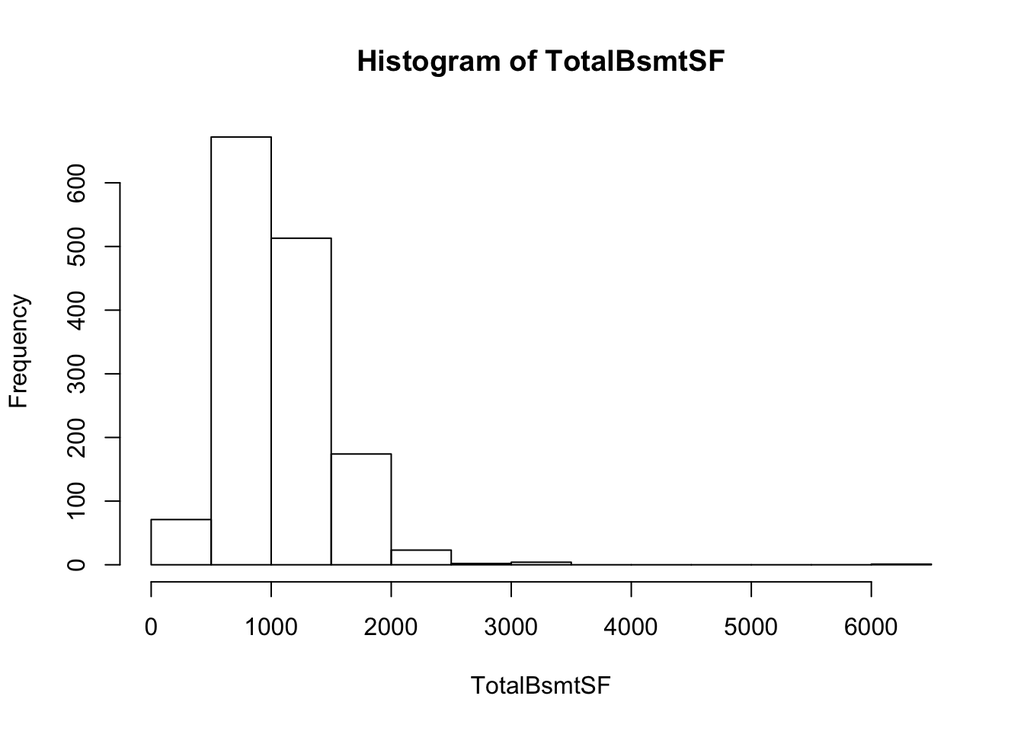

```r
hist(X, xlab="TotalBsmtSF", main = "Histogram of TotalBsmtSF")
```

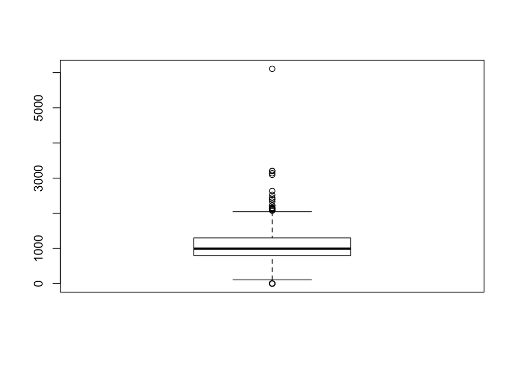

```r
boxplot(X)
```

```r
summary(Y)
```

```
##    Min. 1st Qu.  Median    Mean 3rd Qu.    Max.
##   34900  129975  163000  180921  214000  755000
```

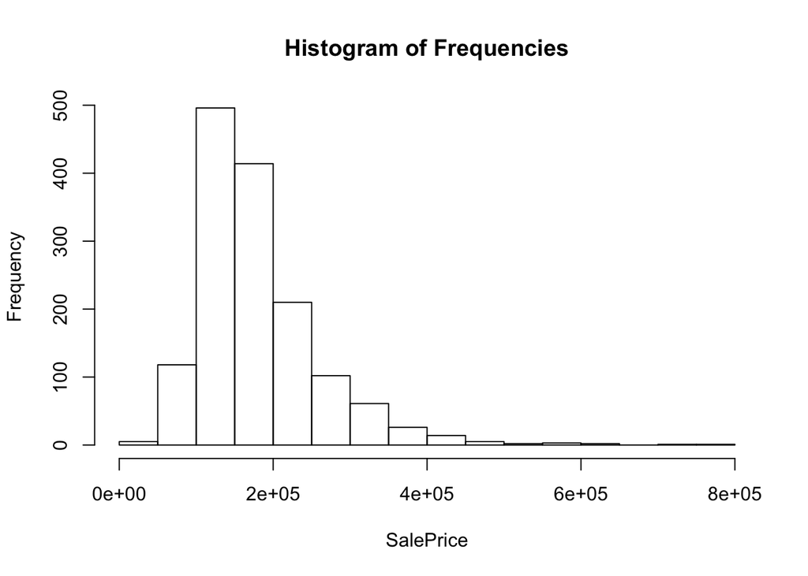

```r
hist(Y, xlab="SalePrice", main = "Histogram of Frequencies")
```

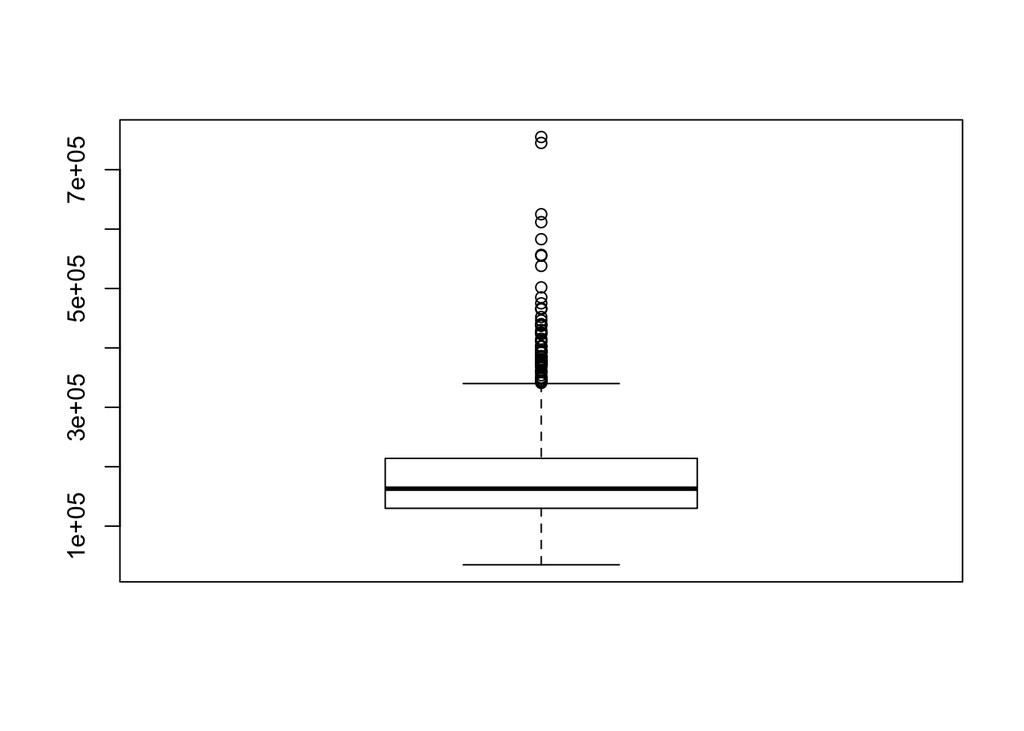

```r
boxplot(Y)
```

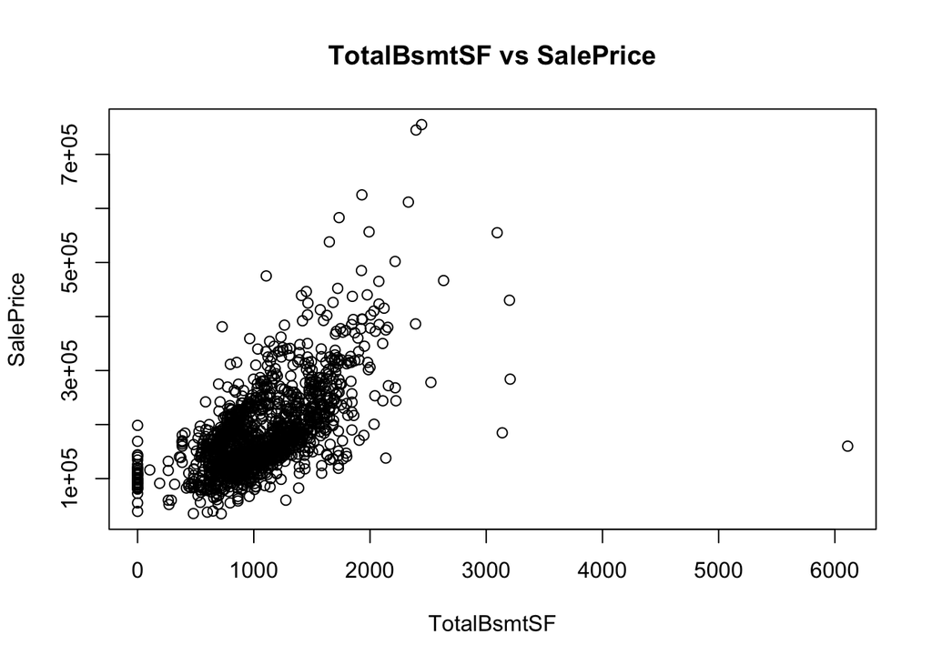

```r
plot(X,Y, xlab='TotalBsmtSF', ylab='SalePrice', main='TotalBsmtSF vs SalePrice')
```

[figure not shown]

```r
Z <- train$LotFrontage
plot(X,Z, xlab='LotFrontage', ylab='SalePrice', main='LotFrontage vs SalePrice')
```

### Correlation Matrix

```
##             TotalBsmtSF GrLivArea SalePrice
## TotalBsmtSF        1.00      0.45      0.61
## GrLivArea          0.45      1.00      0.71
## SalePrice          0.61      0.71      1.00
```

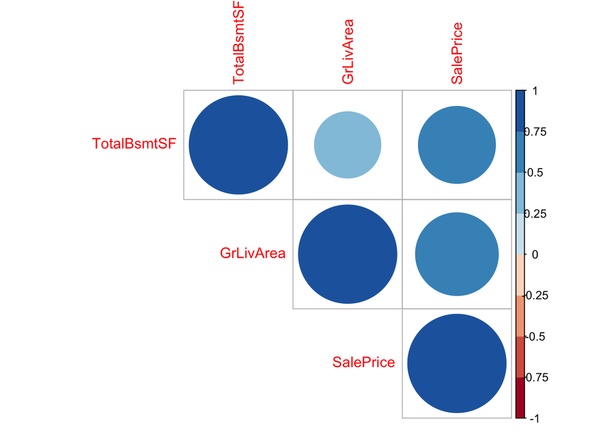

The above plot shows the correlation coefficients in colors (blue for positive correlation and red for negative correlation).

### Test hypotheses at 80% confidence interval

### TotalBsmtSF vs GrLivArea

```r
cor.test(train$TotalBsmtSF, train$GrLivArea, conf.level = 0.80, method = "pearson")
```

```
##
##  Pearson's product-moment correlation
##
## data:  train$TotalBsmtSF and train$GrLivArea
## t = 19.503, df = 1458, p-value < 2.2e-16
## alternative hypothesis: true correlation is not equal to 0
## 80 percent confidence interval:
##  0.4278380 0.4810855
## sample estimates:
##       cor
## 0.4548682
```

### GrLivArea vs SalePrice

```r
cor.test(train$GrLivArea, train$SalePrice, conf.level = 0.80, method = "pearson")
```

```
##
##  Pearson's product-moment correlation
##
## data:  train$GrLivArea and train$SalePrice
## t = 38.348, df = 1458, p-value < 2.2e-16
## alternative hypothesis: true correlation is not equal to 0
## 80 percent confidence interval:
##  0.6915087 0.7249450
## sample estimates:
##       cor
## 0.7086245
```

### TotalBsmtSF vs SalePrice

```r
cor.test(train$TotalBsmtSF, train$SalePrice, conf.level = 0.80, method = "pearson")
```

```
##
##  Pearson's product-moment correlation
##
## data:  train$TotalBsmtSF and train$SalePrice
## t = 29.671, df = 1458, p-value < 2.2e-16
## alternative hypothesis: true correlation is not equal to 0
## 80 percent confidence interval:
##  0.5922142 0.6340846
## sample estimates:
##       cor
## 0.6135806
```

Conclusion : In all the above three tests, null hypothesis is rejected in favor of alternate hypothesis.

### Would you be worried about familywise error? Why or why not?

Familywise errors are based on Type 1 or Type 2 errors. We should be worried when we observe extremely low p value and moderate values of correlation coefficients. Here it is not the case. So I am not worried about it.

## Linear Algebra and Correlation

Correlation matrix

```r
corr_matrix
```

```
##             TotalBsmtSF GrLivArea SalePrice
## TotalBsmtSF   1.0000000 0.4548682 0.6135806
## GrLivArea     0.4548682 1.0000000 0.7086245
## SalePrice     0.6135806 0.7086245 1.0000000
```

Invert the correlation matrix

```
##             TotalBsmtSF   GrLivArea  SalePrice
## TotalBsmtSF  1.60588442 -0.06473842 -0.9394642
## GrLivArea   -0.06473842  2.01124151 -1.3854927
## SalePrice   -0.93946422 -1.38549273  2.5582310
```

Multiply the correlation matrix by the precision matrix, and then multiply the precision matrix by the correlation matrix.

```r
round(corr_matrix %*%  precision_matrix)
```

```
##             TotalBsmtSF GrLivArea SalePrice
## TotalBsmtSF           1         0         0
## GrLivArea             0         1         0
## SalePrice             0         0         1
```

```r
round(precision_matrix %*%  corr_matrix)
```

```
##             TotalBsmtSF GrLivArea SalePrice
## TotalBsmtSF           1         0         0
## GrLivArea             0         1         0
## SalePrice             0         0         1
```

In both cases Identity matrix is obtained.

### LU Decomposition

```r
(LU <- lu.decomposition(precision_matrix))
```

```
## $L
##             [,1]       [,2] [,3]
## [1,]  1.00000000  0.0000000    0
## [2,] -0.04031325  1.0000000    0
## [3,] -0.58501360 -0.7086245    1
##
## $U
##          [,1]        [,2]       [,3]
## [1,] 1.605884 -0.06473842 -0.9394642
## [2,] 0.000000  2.00863169 -1.4233656
## [3,] 0.000000  0.00000000  1.0000000
```

## Calculus-Based Probability & Statistics

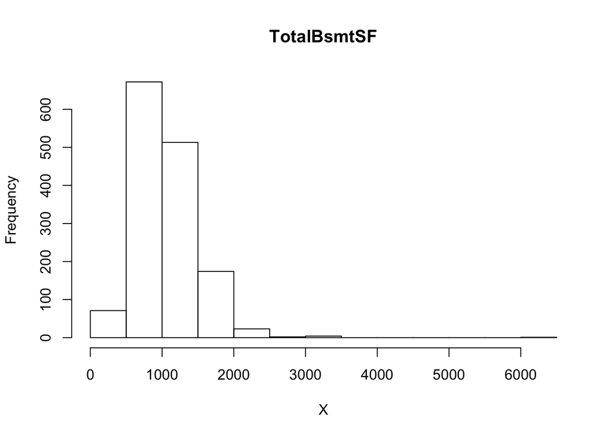

```r
X <- train$TotalBsmtSF
hist(X, main = "TotalBsmtSF")
```

```r
skewness(X)
```

```
## [1] 1.522688
```

```r
summary(X)
```

```
##    Min. 1st Qu.  Median    Mean 3rd Qu.    Max.
##     0.0   795.8   991.5  1057.4  1298.2  6110.0
```

TotalBsmtSF is skewed to right.

Shifting above 0 since min value is 0

```r
X <- X + 1
lamda <- fitdistr(X, 'exponential')
lamda$estimate
```

```
##         rate
## 0.0009447961
```

The optimum of lambda is 0.0009447961

### Take 1000 samples

```r
sample <- rexp(1000, lamda$estimate)
```

### Plot a histogram and compare it with a histogram of your original variable.

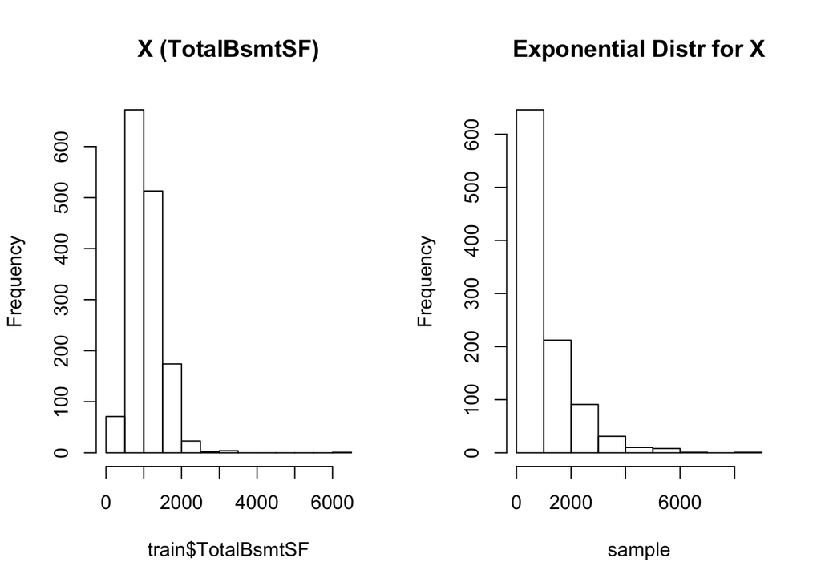

```r
# Compare the two histograms side-by-side.
par(mfrow=c(1, 2))
hist(train$TotalBsmtSF, main="X (TotalBsmtSF)")
hist(sample, main="Exponential Distr for X")
```

```r
# For X
quantile(train$TotalBsmtSF, probs=c(0.05, 0.95))
```

```
##     5%    95%
##  519.3 1753.0
```

```r
# For sample
quantile(sample, probs=c(0.05, 0.95))
```

```
##         5%        95%
##   65.01865 3054.38949
```

```r
# Generate 95% confidence interval for the emperical data:

sd = sd(X)
mean = mean(X)
n = length(X)

err = qnorm(0.975)*sd/sqrt(n)
left = mean - err
right = mean + err

cat("A 95% confidence interval for TotalBsmtSF is [", left, ",", right, "]")
```

```
## A 95% confidence interval for TotalBsmtSF is [ 1035.926 , 1080.933 ]
```

## Modeling

```r
train <- read.csv("/Users/bchand005c/CUNY/DATA-605/assignment/final/train.csv", header = TRUE)
df.train <- as.data.frame(train)
summary(df.train)
```

```
##        Id           MSSubClass       MSZoning     LotFrontage
##  Min.   :   1.0   Min.   : 20.0   C (all):  10   Min.   : 21.00
##  1st Qu.: 365.8   1st Qu.: 20.0   FV     :  65   1st Qu.: 59.00
##  Median : 730.5   Median : 50.0   RH     :  16   Median : 69.00
##  Mean   : 730.5   Mean   : 56.9   RL     :1151   Mean   : 70.05
##  3rd Qu.:1095.2   3rd Qu.: 70.0   RM     : 218   3rd Qu.: 80.00
##  Max.   :1460.0   Max.   :190.0                  Max.   :313.00
##                                                  NA's   :259
##     LotArea        Street      Alley      LotShape  LandContour
##  Min.   :  1300   Grvl:   6   Grvl:  50   IR1:484   Bnk:  63
##  1st Qu.:  7554   Pave:1454   Pave:  41   IR2: 41   HLS:  50
##  Median :  9478               NA's:1369   IR3: 10   Low:  36
##  Mean   : 10517                           Reg:925   Lvl:1311
##  3rd Qu.: 11602
##  Max.   :215245
##
##   Utilities      LotConfig    LandSlope   Neighborhood   Condition1
##  AllPub:1459   Corner : 263   Gtl:1382   NAmes  :225   Norm   :1260
##  NoSeWa:   1   CulDSac:  94   Mod:  65   CollgCr:150   Feedr  :  81
##                FR2    :  47   Sev:  13   OldTown:113   Artery :  48
##                FR3    :   4              Edwards:100   RRAn   :  26
##                Inside :1052              Somerst: 86   PosN   :  19
##                                          Gilbert: 79   RRAe   :  11
##                                          (Other):707   (Other):  15
##    Condition2     BldgType      HouseStyle   OverallQual
##  Norm   :1445   1Fam  :1220   1Story :726   Min.   : 1.000
##  Feedr  :   6   2fmCon:  31   2Story :445   1st Qu.: 5.000
##  Artery :   2   Duplex:  52   1.5Fin :154   Median : 6.000
##  PosN   :   2   Twnhs :  43   SLvl   : 65   Mean   : 6.099
##  RRNn   :   2   TwnhsE: 114   SFoyer : 37   3rd Qu.: 7.000
##  PosA   :   1                 1.5Unf : 14   Max.   :10.000
##  (Other):   2                 (Other): 19
##   OverallCond      YearBuilt     YearRemodAdd    RoofStyle
##  Min.   :1.000   Min.   :1872   Min.   :1950   Flat   :  13
##  1st Qu.:5.000   1st Qu.:1954   1st Qu.:1967   Gable  :1141
##  Median :5.000   Median :1973   Median :1994   Gambrel:  11
##  Mean   :5.575   Mean   :1971   Mean   :1985   Hip    : 286
##  3rd Qu.:6.000   3rd Qu.:2000   3rd Qu.:2004   Mansard:   7
##  Max.   :9.000   Max.   :2010   Max.   :2010   Shed   :   2
##
```

[output cut: 89 more lines]

```
##  GdPrv:  59   Gar2:   2   Min.   :    0.00   Min.   : 1.000
##  GdWo :  54   Othr:   2   1st Qu.:    0.00   1st Qu.: 5.000
##  MnPrv: 157   Shed:  49   Median :    0.00   Median : 6.000
##  MnWw :  11   TenC:   1   Mean   :   43.49   Mean   : 6.322
##  NA's :1179   NA's:1406   3rd Qu.:    0.00   3rd Qu.: 8.000
##                           Max.   :15500.00   Max.   :12.000
##
##      YrSold        SaleType    SaleCondition    SalePrice
##  Min.   :2006   WD     :1267   Abnorml: 101   Min.   : 34900
##  1st Qu.:2007   New    : 122   AdjLand:   4   1st Qu.:129975
##  Median :2008   COD    :  43   Alloca :  12   Median :163000
##  Mean   :2008   ConLD  :   9   Family :  20   Mean   :180921
##  3rd Qu.:2009   ConLI  :   5   Normal :1198   3rd Qu.:214000
##  Max.   :2010   ConLw  :   5   Partial: 125   Max.   :755000
##                 (Other):   9
```

Based on summary stats, removing fields that are missing data

```r
df.train <- df.train %>% dplyr::select(-c(Street, Alley, LandContour, Utilities,
                           LandSlope, Condition2, MasVnrArea, Heating,
                           BsmtFinSF2, X2ndFlrSF, LowQualFinSF, BsmtFullBath,
                           BsmtHalfBath, HalfBath, PoolQC, PoolArea, MiscVal,
                           MiscFeature, Fence, ScreenPorch, Fireplaces,
                           EnclosedPorch, MoSold, YrSold))
```

Convert categorical variables to numerical values

```r
df.train <- df.train %>% mutate_if(is.factor, as.numeric)
```

Replace NA with 0

```r
df.train <- df.train %>% replace(is.na(.), 0)
```

Convert sales price to log values as feature engineering

```r
df.train$SalePrice <- log(df.train$SalePrice)
```

Build initial model with all selected features

```r
sale_price_lm <- lm(SalePrice ~ . , data=df.train)
summary(sale_price_lm)
```

```
##
## Call:
## lm(formula = SalePrice ~ ., data = df.train)
##
## Residuals:
##      Min       1Q   Median       3Q      Max
## -1.98665 -0.06503  0.00333  0.07143  0.57305
##
## Coefficients:
##                 Estimate Std. Error t value Pr(>|t|)
## (Intercept)    6.263e+00  6.923e-01   9.046  < 2e-16 ***
## Id            -1.212e-05  9.085e-06  -1.334 0.182571
## MSSubClass    -1.327e-04  2.020e-04  -0.657 0.511138
## MSZoning      -1.829e-02  6.722e-03  -2.720 0.006601 **
## LotFrontage   -2.952e-04  1.239e-04  -2.382 0.017346 *
## LotArea        1.757e-06  4.240e-07   4.143 3.63e-05 ***
## LotShape      -4.811e-03  3.027e-03  -1.589 0.112256
## LotConfig     -7.497e-04  2.426e-03  -0.309 0.757349
## Neighborhood   6.277e-04  6.990e-04   0.898 0.369385
## Condition1     8.491e-04  4.511e-03   0.188 0.850728
## BldgType      -1.298e-02  6.647e-03  -1.953 0.050999 .
## HouseStyle    -4.242e-03  2.859e-03  -1.484 0.138073
## OverallQual    7.419e-02  5.253e-03  14.124  < 2e-16 ***
## OverallCond    3.754e-02  4.607e-03   8.150 8.00e-16 ***
## YearBuilt      1.250e-03  3.085e-04   4.050 5.39e-05 ***
## YearRemodAdd   8.181e-04  2.969e-04   2.755 0.005941 **
## RoofStyle      5.350e-03  4.969e-03   1.077 0.281800
## RoofMatl       1.606e-02  6.649e-03   2.416 0.015827 *
## Exterior1st   -4.906e-03  2.325e-03  -2.110 0.035024 *
## Exterior2nd    4.302e-03  2.108e-03   2.041 0.041393 *
## MasVnrType     4.479e-03  6.208e-03   0.721 0.470734
## ExterQual     -3.391e-03  8.703e-03  -0.390 0.696846
## ExterCond      1.204e-02  5.615e-03   2.145 0.032156 *
## Foundation     1.030e-02  7.501e-03   1.374 0.169710
## BsmtQual      -1.575e-02  6.061e-03  -2.599 0.009455 **
## BsmtCond       1.041e-02  5.840e-03   1.783 0.074761 .
## BsmtExposure  -9.066e-03  3.883e-03  -2.335 0.019680 *
## BsmtFinType1  -8.410e-03  2.769e-03  -3.037 0.002431 **
## BsmtFinSF1    -9.490e-05  3.327e-05  -2.852 0.004402 **
## BsmtFinType2   1.922e-02  4.996e-03   3.846 0.000125 ***
```

[output cut: 18 more lines]

```
## GarageArea    -1.137e-05  4.134e-05  -0.275 0.783365
## GarageQual    -1.656e-03  7.914e-03  -0.209 0.834318
## GarageCond     1.083e-02  8.967e-03   1.208 0.227274
## PavedDrive     2.571e-02  9.251e-03   2.780 0.005511 **
## WoodDeckSF     8.216e-05  3.309e-05   2.482 0.013163 *
## OpenPorchSF   -2.759e-05  6.341e-05  -0.435 0.663584
## X3SsnPorch     1.274e-04  1.302e-04   0.978 0.328043
## SaleType      -1.191e-03  2.555e-03  -0.466 0.641310
## SaleCondition  2.281e-02  3.681e-03   6.196 7.62e-10 ***
## ---
## Signif. codes:  0 '***' 0.001 '**' 0.01 '*' 0.05 '.' 0.1 ' ' 1
##
## Residual standard error: 0.143 on 1403 degrees of freedom
## Multiple R-squared:  0.8768, Adjusted R-squared:  0.8719
## F-statistic: 178.3 on 56 and 1403 DF,  p-value: < 2.2e-16
```

Performs stepwise model selection by AIC.

```r
aic_lm <- stepAIC(sale_price_lm, trace=FALSE)
summary(aic_lm)
```

```
##
## Call:
## lm(formula = SalePrice ~ MSZoning + LotFrontage + LotArea + LotShape +
##     BldgType + HouseStyle + OverallQual + OverallCond + YearBuilt +
##     YearRemodAdd + RoofMatl + Exterior1st + Exterior2nd + ExterCond +
##     BsmtQual + BsmtCond + BsmtExposure + BsmtFinType1 + BsmtFinSF1 +
##     BsmtFinType2 + BsmtUnfSF + TotalBsmtSF + HeatingQC + CentralAir +
##     GrLivArea + FullBath + KitchenAbvGr + KitchenQual + TotRmsAbvGrd +
##     Functional + FireplaceQu + GarageType + GarageCars + GarageCond +
##     PavedDrive + WoodDeckSF + SaleCondition, data = df.train)
##
## Residuals:
##      Min       1Q   Median       3Q      Max
## -2.02454 -0.06521  0.00175  0.07304  0.57445
##
## Coefficients:
##                 Estimate Std. Error t value Pr(>|t|)
## (Intercept)    5.949e+00  6.284e-01   9.467  < 2e-16 ***
## MSZoning      -1.981e-02  6.398e-03  -3.097 0.001995 **
## LotFrontage   -2.688e-04  1.222e-04  -2.199 0.028038 *
## LotArea        1.751e-06  4.198e-07   4.170 3.23e-05 ***
## LotShape      -5.663e-03  2.933e-03  -1.931 0.053712 .
## BldgType      -1.738e-02  3.801e-03  -4.572 5.24e-06 ***
## HouseStyle    -5.973e-03  2.472e-03  -2.417 0.015794 *
## OverallQual    7.514e-02  5.068e-03  14.826  < 2e-16 ***
## OverallCond    3.708e-02  4.550e-03   8.151 7.84e-16 ***
## YearBuilt      1.394e-03  2.790e-04   4.996 6.59e-07 ***
## YearRemodAdd   8.705e-04  2.882e-04   3.020 0.002570 **
## RoofMatl       1.630e-02  6.507e-03   2.505 0.012360 *
## Exterior1st   -5.157e-03  2.294e-03  -2.248 0.024728 *
## Exterior2nd    4.236e-03  2.071e-03   2.045 0.041013 *
## ExterCond      1.207e-02  5.505e-03   2.192 0.028571 *
## BsmtQual      -1.890e-02  5.743e-03  -3.290 0.001026 **
## BsmtCond       9.121e-03  5.697e-03   1.601 0.109590
## BsmtExposure  -8.670e-03  3.674e-03  -2.360 0.018401 *
## BsmtFinType1  -8.934e-03  2.724e-03  -3.280 0.001065 **
## BsmtFinSF1    -8.910e-05  3.274e-05  -2.721 0.006586 **
## BsmtFinType2   1.757e-02  4.878e-03   3.602 0.000326 ***
## BsmtUnfSF     -1.389e-04  3.227e-05  -4.304 1.80e-05 ***
## TotalBsmtSF    1.967e-04  3.140e-05   6.264 4.95e-10 ***
## HeatingQC     -9.599e-03  2.651e-03  -3.621 0.000304 ***
## CentralAir     8.869e-02  1.852e-02   4.789 1.85e-06 ***
## GrLivArea      1.818e-04  1.704e-05  10.666  < 2e-16 ***
## FullBath       2.032e-02  1.062e-02   1.913 0.055926 .
## KitchenAbvGr  -3.143e-02  2.128e-02  -1.476 0.140033
## KitchenQual   -2.830e-02  5.971e-03  -4.739 2.36e-06 ***
## TotRmsAbvGrd   1.649e-02  4.605e-03   3.582 0.000353 ***
## Functional     1.551e-02  4.073e-03   3.809 0.000146 ***
## FireplaceQu    1.011e-02  2.171e-03   4.657 3.51e-06 ***
## GarageType    -7.093e-03  2.551e-03  -2.780 0.005503 **
## GarageCars     7.160e-02  8.293e-03   8.634  < 2e-16 ***
## GarageCond     9.459e-03  4.389e-03   2.155 0.031316 *
## PavedDrive     2.481e-02  9.140e-03   2.714 0.006724 **
## WoodDeckSF     8.289e-05  3.265e-05   2.539 0.011225 *
## SaleCondition  2.234e-02  3.562e-03   6.271 4.74e-10 ***
## ---
## Signif. codes:  0 '***' 0.001 '**' 0.01 '*' 0.05 '.' 0.1 ' ' 1
##
## Residual standard error: 0.1426 on 1422 degrees of freedom
## Multiple R-squared:  0.8758, Adjusted R-squared:  0.8725
## F-statistic: 270.9 on 37 and 1422 DF,  p-value: < 2.2e-16
```

Check R squared value

```r
summary(aic_lm)$r.squared
```

```
## [1] 0.8757536
```

High value of R squared makes our model good fit of data.

Checking the validity of model

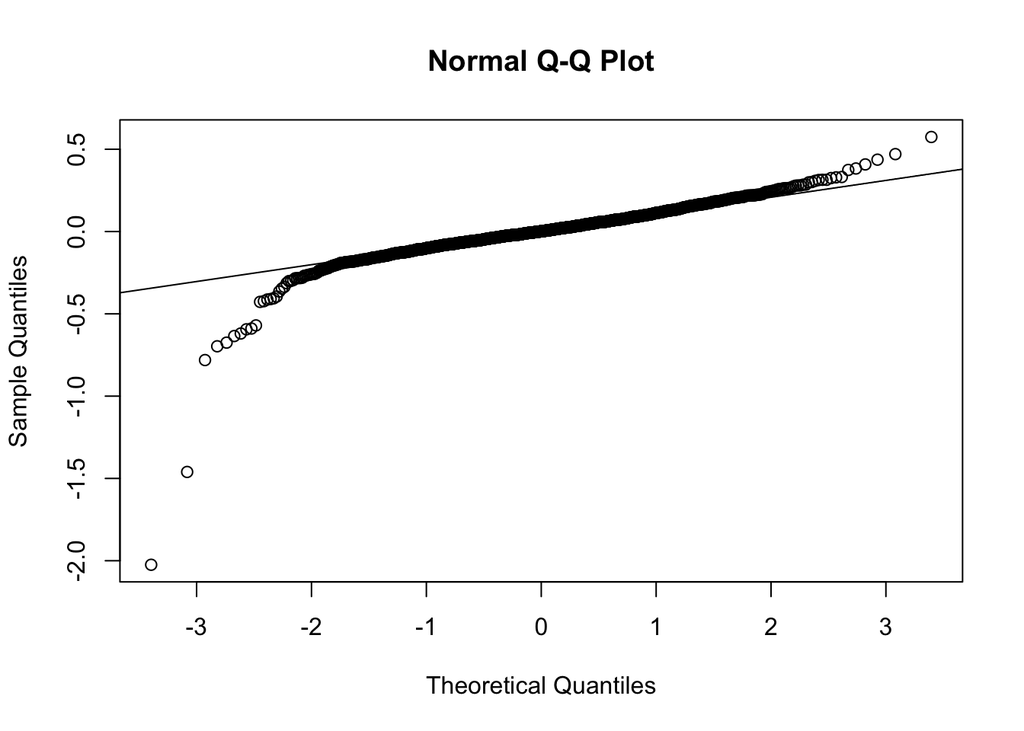

```r
qqnorm(aic_lm$residuals); qqline(aic_lm$residuals)
```

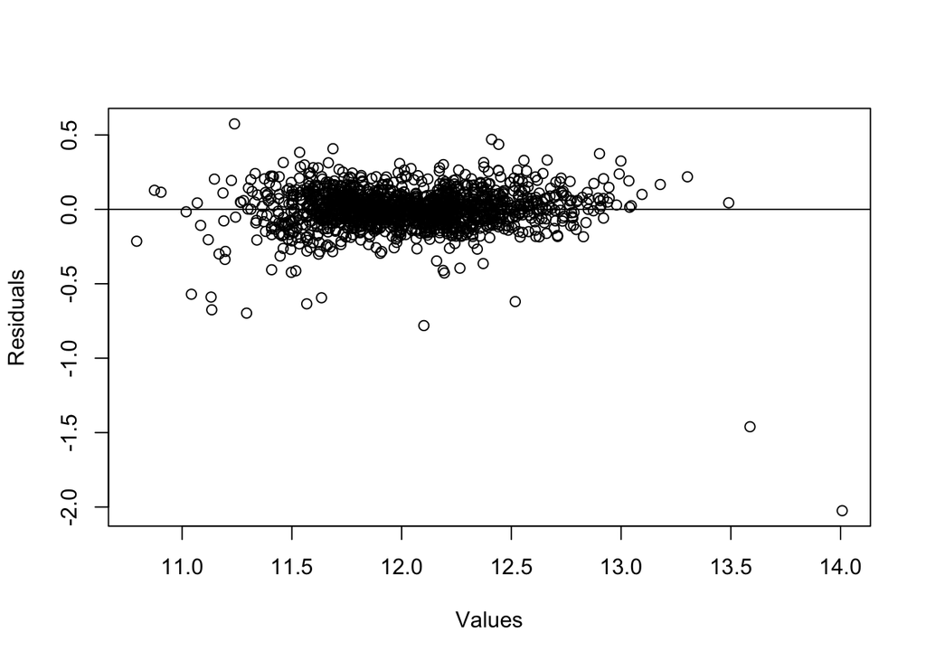

```r
plot(aic_lm$fitted.values, aic_lm$residuals,
     xlab="Values", ylab="Residuals")
abline(h=0)
```

Prediction

```r
test <- read.csv("/Users/bchand005c/CUNY/DATA-605/assignment/final/test.csv", header = TRUE)
df.test <- as.data.frame(test)
df.test <- df.test %>% dplyr::select(-c(Street, Alley, LandContour, Utilities,
                           LandSlope, Condition2, MasVnrArea, Heating,
                           BsmtFinSF2, X2ndFlrSF, LowQualFinSF, BsmtFullBath,
                           BsmtHalfBath, HalfBath, PoolQC, PoolArea, MiscVal,
                           MiscFeature, Fence, ScreenPorch, Fireplaces,
                           EnclosedPorch, MoSold, YrSold))
df.test <- df.test %>% mutate_if(is.factor, as.numeric)
df.test <- df.test %>% replace(is.na(.), 0)

pred_saleprice <- predict(aic_lm, df.test)
kaggle <- data.frame(Id=test$Id, SalePrice=pred_saleprice)
write.csv(kaggle, file = "submission.csv", row.names=FALSE)
```

Kaggle Submission

```
username : astilavista    score : 9.45492
```